# Homework 12

## Golub leukemia samples

**Skill invocation.** Apply `$compare-clustering` to the 38 rows of `data/golub.csv`, using `gene_1` through `gene_3051` as features. Each row is one sample. Use leukemia type after selecting the clustering.

**Method.** The expression values were already log-transformed and standardized within samples. I centered each gene across samples, dropped any constant genes, and used Euclidean distance in the full gene space. I tried K-means, Ward hierarchical clustering, and partitioning around medoids (PAM), with two to five groups each. I required at least three samples per group and chose the highest average silhouette width. A higher silhouette means samples tend to be closer to their own group than to the nearest other group.

**Results.** K-means with 4 groups gave the highest eligible average silhouette (0.11). After selection, I checked the known leukemia types. Three clusters contained only ALL samples (10, 9, and 8), and the fourth contained all 11 AML samples. The score of 0.11 suggests weak separation in the full gene space, even though each cluster contained only one leukemia type.

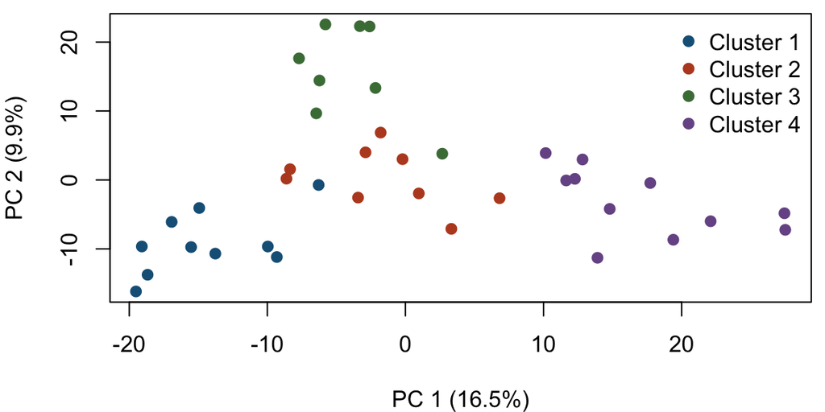

**Limitation.** The plot shows only two directions of variation. Groups were fit using all retained genes, and the small sample size limits conclusions about how well the groups would hold up in new samples.

## Appendix · Complete skill definition

```markdown
---
name: compare-clustering
description: Compare unsupervised clustering algorithms and explain the selected grouping in a one-page report. Use only when explicitly invoked.
---

1. Ask for the dataset location, the unit represented by one row, and the feature columns if these are unclear. Exclude identifiers and known labels from all preprocessing, fitting, tuning, and selection.
2. Check missing values and constant features. Document any imputation, scaling, or dimension reduction. Choose the representation based on feature units and data properties. Use the same representation across candidates and fix seeds for randomized fits.
3. Fit at least three algorithms, for example K-means, Ward hierarchical clustering, and partitioning around medoids (PAM). Try a reasonable range of cluster counts given the sample size. Use multiple starts for K-means. Use the same Euclidean distances to score all candidates when using those three methods.
4. Compare mean silhouette widths in the fitting space. Specify any minimum cluster size before scoring to avoid selecting tiny groups. Select the eligible candidate with the highest mean silhouette. For exact ties prefer fewer clusters, then use the order in which algorithms were listed.
5. Limit the generated analysis report to one printed page total, including all text, figures, and tables. Present clustering results from only the selected method. Briefly name the alternatives and explain the rule used to choose the winner. Plot the selected clusters in a two-dimensional projection with clear axes and state when the fitting space differs. Describe group sizes, interpret any known labels only after selection, and explain a limitation. Check the rendered page before delivery.
```